# 2 Data Preparation

## Importing necessary Libraries

```python
import pandas as pd
import numpy as np
import matplotlib.pyplot as plt
import scipy.stats as stats
```

### 2.1 Importing the Dataset

```python
# Importing the CSV file as dataSet

dataSet = pd.read_csv('Main.csv', low_memory = False )
dataSet.head()
```

|  | Unique Key | Created Date | Closed Date | Agency | Agency Name | Complaint Type | Descriptor | Location Type | Incident Zip | Incident Address | ... | Bridge Highway Name | Bridge Highway Direction | Road Ramp | Bridge Highway Segment | Garage Lot Name | Ferry Direction | Ferry Terminal Name | Latitude | Longitude | Location |
| --- | --- | --- | --- | --- | --- | --- | --- | --- | --- | --- | --- | --- | --- | --- | --- | --- | --- | --- | --- | --- | --- |
| 0 | 32310363 | 12/31/2015 11:59:45 PM | 01-01-16 0:55 | NYPD | New York City Police Department | Noise - Street/Sidewalk | Loud Music/Party | Street/Sidewalk | 10034.0 | 71 VERMILYEA AVENUE | ... | NaN | NaN | NaN | NaN | NaN | NaN | NaN | 40.865682 | -73.923501 | (40.86568153633767, -73.92350095571744) |
| 1 | 32309934 | 12/31/2015 11:59:44 PM | 01-01-16 1:26 | NYPD | New York City Police Department | Blocked Driveway | No Access | Street/Sidewalk | 11105.0 | 27-07 23 AVENUE | ... | NaN | NaN | NaN | NaN | NaN | NaN | NaN | 40.775945 | -73.915094 | (40.775945312321085, -73.91509393898605) |
| 2 | 32309159 | 12/31/2015 11:59:29 PM | 01-01-16 4:51 | NYPD | New York City Police Department | Blocked Driveway | No Access | Street/Sidewalk | 10458.0 | 2897 VALENTINE AVENUE | ... | NaN | NaN | NaN | NaN | NaN | NaN | NaN | 40.870325 | -73.888525 | (40.870324522111424, -73.88852464418646) |
| 3 | 32305098 | 12/31/2015 11:57:46 PM | 01-01-16 7:43 | NYPD | New York City Police Department | Illegal Parking | Commercial Overnight Parking | Street/Sidewalk | 10461.0 | 2940 BAISLEY AVENUE | ... | NaN | NaN | NaN | NaN | NaN | NaN | NaN | 40.835994 | -73.828379 | (40.83599404683083, -73.82837939584206) |
| 4 | 32306529 | 12/31/2015 11:56:58 PM | 01-01-16 3:24 | NYPD | New York City Police Department | Illegal Parking | Blocked Sidewalk | Street/Sidewalk | 11373.0 | 87-14 57 ROAD | ... | NaN | NaN | NaN | NaN | NaN | NaN | NaN | 40.733060 | -73.874170 | (40.733059618956815, -73.87416975810375) |

5 rows × 53 columns

### 2.2 Provide your insight on the information and details that the provided dataset carries.

```python
# Using Describe
dataSet.describe
```

```
<bound method NDFrame.describe of         Unique Key            Created Date             Closed Date Agency  \
0         32310363  12/31/2015 11:59:45 PM           01-01-16 0:55   NYPD
1         32309934  12/31/2015 11:59:44 PM           01-01-16 1:26   NYPD
2         32309159  12/31/2015 11:59:29 PM           01-01-16 4:51   NYPD
3         32305098  12/31/2015 11:57:46 PM           01-01-16 7:43   NYPD
4         32306529  12/31/2015 11:56:58 PM           01-01-16 3:24   NYPD
...            ...                     ...                     ...    ...
300693    30281872  03/29/2015 12:33:41 AM                     NaN   NYPD
300694    30281230  03/29/2015 12:33:28 AM  03/29/2015 02:33:59 AM   NYPD
300695    30283424  03/29/2015 12:33:03 AM  03/29/2015 03:40:20 AM   NYPD
300696    30280004  03/29/2015 12:33:02 AM  03/29/2015 04:38:35 AM   NYPD
300697    30281825  03/29/2015 12:33:01 AM  03/29/2015 04:41:50 AM   NYPD

                            Agency Name           Complaint Type  \
0       New York City Police Department  Noise - Street/Sidewalk
```

[output cut: 77 more lines]

```python
# Using Info

dataSet.info()
```

```
<class 'pandas.core.frame.DataFrame'>
RangeIndex: 300698 entries, 0 to 300697
Data columns (total 53 columns):
 #   Column                          Non-Null Count   Dtype
---  ------                          --------------   -----
 0   Unique Key                      300698 non-null  int64
 1   Created Date                    300698 non-null  object
 2   Closed Date                     298534 non-null  object
 3   Agency                          300698 non-null  object
 4   Agency Name                     300698 non-null  object
 5   Complaint Type                  300698 non-null  object
 6   Descriptor                      294784 non-null  object
 7   Location Type                   300567 non-null  object
 8   Incident Zip                    298083 non-null  float64
 9   Incident Address                256288 non-null  object
```

[output cut: 45 more lines]

### 2.3 Convert the columns "Created Date" and "Closed Date" to the datetime datatype and create a new column "Request_Closing_Time" as the time elapsed between request creation and request closing

```python
#Initial data type of the columns "Created Date" and "Closed Date"

print("The initial data type of the column Created Date: ", dataSet['Created Date'].dtypes)
print("The initial data type of the column  Closed Date: ", dataSet['Closed Date'].dtypes)
```

```
The initial data type of the column Created Date:  object
The initial data type of the column  Closed Date:  object
```

```python
# Converting the datatype of the columns “Created Date” and “Closed Date” to “datetime”

# For Created Date
dataSet['Created Date'] = pd.to_datetime(dataSet['Created Date'], format= "mixed", errors='coerce')

# For Closed Date
dataSet['Closed Date'] = pd.to_datetime(dataSet['Closed Date'], format= "mixed", errors='coerce')
```

```python
# Showing the data type after conversion

Create_date_datatype = dataSet['Created Date'].dtype
Closed_date_datatype = dataSet['Closed Date'].dtype

print(f"The date type of Created Date is : {Create_date_datatype}")
print(f"The date type of Closed Date is : {Closed_date_datatype}")
```

```
The date type of Created Date is : datetime64[ns]
The date type of Closed Date is : datetime64[ns]
```

```python
# Creating new column "Request_Closing_Time" which contains the value after deducting "Created Date" from "Closed Date"

dataSet['Request_Closing_Time'] = (dataSet['Closed Date'] - dataSet['Created Date'])
dataSet.head()
```

|  | Unique Key | Created Date | Closed Date | Agency | Agency Name | Complaint Type | Descriptor | Location Type | Incident Zip | Incident Address | ... | Bridge Highway Direction | Road Ramp | Bridge Highway Segment | Garage Lot Name | Ferry Direction | Ferry Terminal Name | Latitude | Longitude | Location | Request_Closing_Time |
| --- | --- | --- | --- | --- | --- | --- | --- | --- | --- | --- | --- | --- | --- | --- | --- | --- | --- | --- | --- | --- | --- |
| 0 | 32310363 | 2015-12-31 23:59:45 | 2016-01-01 00:55:00 | NYPD | New York City Police Department | Noise - Street/Sidewalk | Loud Music/Party | Street/Sidewalk | 10034.0 | 71 VERMILYEA AVENUE | ... | NaN | NaN | NaN | NaN | NaN | NaN | 40.865682 | -73.923501 | (40.86568153633767, -73.92350095571744) | 0 days 00:55:15 |
| 1 | 32309934 | 2015-12-31 23:59:44 | 2016-01-01 01:26:00 | NYPD | New York City Police Department | Blocked Driveway | No Access | Street/Sidewalk | 11105.0 | 27-07 23 AVENUE | ... | NaN | NaN | NaN | NaN | NaN | NaN | 40.775945 | -73.915094 | (40.775945312321085, -73.91509393898605) | 0 days 01:26:16 |
| 2 | 32309159 | 2015-12-31 23:59:29 | 2016-01-01 04:51:00 | NYPD | New York City Police Department | Blocked Driveway | No Access | Street/Sidewalk | 10458.0 | 2897 VALENTINE AVENUE | ... | NaN | NaN | NaN | NaN | NaN | NaN | 40.870325 | -73.888525 | (40.870324522111424, -73.88852464418646) | 0 days 04:51:31 |
| 3 | 32305098 | 2015-12-31 23:57:46 | 2016-01-01 07:43:00 | NYPD | New York City Police Department | Illegal Parking | Commercial Overnight Parking | Street/Sidewalk | 10461.0 | 2940 BAISLEY AVENUE | ... | NaN | NaN | NaN | NaN | NaN | NaN | 40.835994 | -73.828379 | (40.83599404683083, -73.82837939584206) | 0 days 07:45:14 |
| 4 | 32306529 | 2015-12-31 23:56:58 | 2016-01-01 03:24:00 | NYPD | New York City Police Department | Illegal Parking | Blocked Sidewalk | Street/Sidewalk | 11373.0 | 87-14 57 ROAD | ... | NaN | NaN | NaN | NaN | NaN | NaN | 40.733060 | -73.874170 | (40.733059618956815, -73.87416975810375) | 0 days 03:27:02 |

5 rows × 54 columns

### 2.4 Write a Python program to drop the irrelevant Columns which are listed below.

```python
# Storing the irrelevant columns in a list

to_remove =['Agency Name','Incident Address','Street Name','Cross Street 1','Cross Street 2','Intersection Street 1',
            'Intersection Street 2','Address Type','Park Facility Name','Park Borough','School Name', 'School Number','School Region',
            'School Code','School Phone Number','School Address','School City', 'School State','School Zip','School Not Found',
            'School or Citywide Complaint','Vehicle Type', 'Taxi Company Borough','Taxi Pick Up Location','Bridge Highway Name',
            'Bridge Highway Direction', 'Road Ramp','Bridge Highway Segment','Garage Lot Name','Ferry Direction','Ferry Terminal Name','Landmark',
            'X Coordinate (State Plane)','Y Coordinate (State Plane)','Due Date','Resolution Action Updated Date','Community Board',
            'Facility Type', 'Location']
```

```python
#  Initial total number of columns

total_columns = dataSet.shape[1]
print(f"Initial number of columns: {total_columns}")

# Removing Columns

dataSet = dataSet.drop(to_remove, axis="columns")

# Counting the total number of leftover columns

total_columns = dataSet.shape[1]
print(f"Remaining number of columns: {total_columns}")
```

```
Initial number of columns: 54
Remaining number of columns: 15
```

### 2.5 Write a python program to remove the NaN missing values from updated dataframe.

```python
#  Initial total number of rows

total_rows = dataSet.shape[0]
print(f"Total number of rows before: {total_rows}")
```

```
Total number of rows before: 300698
```

```python
# Count missing values (NaT or NaN) in each column
missing_values_created = dataSet['Created Date'].isna().sum()
missing_values_closed = dataSet['Closed Date'].isna().sum()

# Print the results
print(f"Missing values in 'Created Date': {missing_values_created}")
print(f"Missing values in 'Closed Date': {missing_values_closed}")
```

```
Missing values in 'Created Date': 0
Missing values in 'Closed Date': 2164
```

```python
# Removing rows with NaN data

dataSet = dataSet.dropna()

# Calculating the remaining number of rows

total_rows = dataSet.shape[0]
print(f"Total number of remaining rows: {total_rows}")
```

```
Total number of remaining rows: 291107
```

### 2.6 Write a python program to see the unique values from all the columns in the dataframe.

```python
#Using For Loop to Find the unique values from the column

for column in dataSet.columns:
    print(f"\nUnique values in '{column}':")
    print(dataSet[column].unique())
```

```
Unique values in 'Unique Key':
[32310363 32309934 32309159 ... 30283424 30280004 30281825]

Unique values in 'Created Date':
<DatetimeArray>
['2015-12-31 23:59:45', '2015-12-31 23:59:44', '2015-12-31 23:59:29',
 '2015-12-31 23:57:46', '2015-12-31 23:56:58', '2015-12-31 23:56:30',
 '2015-12-31 23:55:32', '2015-12-31 23:54:05', '2015-12-31 23:53:58',
 '2015-12-31 23:52:58',
 ...
 '2015-03-29 00:42:48', '2015-03-29 00:37:15', '2015-03-29 00:35:28',
 '2015-03-29 00:35:23', '2015-03-29 00:35:04', '2015-03-29 00:34:32',
 '2015-03-29 00:33:28', '2015-03-29 00:33:03', '2015-03-29 00:33:02',
 '2015-03-29 00:33:01']
Length: 251970, dtype: datetime64[ns]

Unique values in 'Closed Date':
<DatetimeArray>
['2016-01-01 00:55:00', '2016-01-01 01:26:00', '2016-01-01 04:51:00',
 '2016-01-01 07:43:00', '2016-01-01 03:24:00', '2016-01-01 01:50:00',
 '2016-01-01 01:53:00', '2016-01-01 01:42:00', '2016-01-01 08:27:00',
 '2016-01-01 01:17:00',
 ...
 '2015-03-29 00:57:23', '2015-03-29 02:57:41', '2015-03-29 01:02:39',
 '2015-03-29 04:14:27', '2015-03-29 08:41:24', '2015-03-29 02:52:28',
 '2015-03-29 01:13:01', '2015-03-29 02:33:59', '2015-03-29 04:38:35',
 '2015-03-29 04:41:50']
Length: 231991, dtype: datetime64[ns]

Unique values in 'Agency':
['NYPD']

Unique values in 'Complaint Type':
['Noise - Street/Sidewalk' 'Blocked Driveway' 'Illegal Parking'
 'Derelict Vehicle' 'Noise - Commercial' 'Noise - House of Worship'
 'Posting Advertisement' 'Noise - Vehicle' 'Animal Abuse' 'Vending'
 'Traffic' 'Drinking' 'Noise - Park' 'Graffiti' 'Disorderly Youth']

Unique values in 'Descriptor':
['Loud Music/Party' 'No Access' 'Commercial Overnight Parking'
```

[output cut: 77 more lines]

```

Unique values in 'Longitude':
[-73.92350096 -73.91509394 -73.88852464 ... -73.94880526 -73.87124456
 -73.9913785 ]

Unique values in 'Request_Closing_Time':
<TimedeltaArray>
['0 days 00:55:15', '0 days 01:26:16', '0 days 04:51:31', '0 days 07:45:14',
 '0 days 03:27:02', '0 days 01:53:30', '0 days 01:57:28', '0 days 01:47:55',
 '0 days 08:33:02', '0 days 01:23:02',
 ...
 '0 days 06:46:59', '0 days 07:28:23', '0 days 05:13:46', '0 days 05:19:11',
 '0 days 10:22:47', '0 days 09:46:41', '0 days 15:40:46', '0 days 04:44:52',
 '0 days 09:44:44', '0 days 15:42:26']
Length: 47134, dtype: timedelta64[ns]
```

# 3 Data Analysis

### 3.1 Write a Python program to show summary statistics of sum, mean, standard deviation, skewness, and kurtosis of the data frame.

```python
# Importing skew and kurtosis

from scipy.stats import skew, kurtosis
```

```python
# As we see, most of the columns have an Object Data type

dataSet.info()
```

```
<class 'pandas.core.frame.DataFrame'>
Index: 291107 entries, 0 to 300697
Data columns (total 15 columns):
 #   Column                  Non-Null Count   Dtype
---  ------                  --------------   -----
 0   Unique Key              291107 non-null  int64
 1   Created Date            291107 non-null  datetime64[ns]
 2   Closed Date             291107 non-null  datetime64[ns]
 3   Agency                  291107 non-null  object
 4   Complaint Type          291107 non-null  object
 5   Descriptor              291107 non-null  object
 6   Location Type           291107 non-null  object
 7   Incident Zip            291107 non-null  float64
 8   City                    291107 non-null  object
 9   Status                  291107 non-null  object
 10  Resolution Description  291107 non-null  object
 11  Borough                 291107 non-null  object
 12  Latitude                291107 non-null  float64
 13  Longitude               291107 non-null  float64
 14  Request_Closing_Time    291107 non-null  timedelta64[ns]
dtypes: datetime64[ns](2), float64(3), int64(1), object(8), timedelta64[ns](1)
memory usage: 35.5+ MB
```

```python
#  We will be working on the Request Closing time only after converting its data type to int
# Here, a new column 'Request_Closing_Time_Int' is created where the conversion is stored

dataSet['Request_Closing_Time_Int'] = dataSet['Request_Closing_Time'].dt.total_seconds().astype(int)
dataSet['Request_Closing_Time_Int'].dtype
```

```
dtype('int64')
```

```python
dataSet.info()
```

```
<class 'pandas.core.frame.DataFrame'>
Index: 291107 entries, 0 to 300697
Data columns (total 16 columns):
 #   Column                    Non-Null Count   Dtype
---  ------                    --------------   -----
 0   Unique Key                291107 non-null  int64
 1   Created Date              291107 non-null  datetime64[ns]
 2   Closed Date               291107 non-null  datetime64[ns]
 3   Agency                    291107 non-null  object
 4   Complaint Type            291107 non-null  object
 5   Descriptor                291107 non-null  object
 6   Location Type             291107 non-null  object
 7   Incident Zip              291107 non-null  float64
 8   City                      291107 non-null  object
 9   Status                    291107 non-null  object
 10  Resolution Description    291107 non-null  object
 11  Borough                   291107 non-null  object
 12  Latitude                  291107 non-null  float64
 13  Longitude                 291107 non-null  float64
 14  Request_Closing_Time      291107 non-null  timedelta64[ns]
 15  Request_Closing_Time_Int  291107 non-null  int64
dtypes: datetime64[ns](2), float64(3), int64(2), object(8), timedelta64[ns](1)
memory usage: 37.8+ MB
```

```python
# Calculating Summary Statistics

summary_stats = pd.DataFrame({
    'Sum': [dataSet['Request_Closing_Time_Int'].sum()], # Sum
    'Mean': [dataSet['Request_Closing_Time_Int'].mean()], #Mean
    'Standard Deviation': [dataSet['Request_Closing_Time_Int'].std()], #Standard Deviation
    'Skewness': [dataSet['Request_Closing_Time_Int'].skew()], #Skewness
    'Kurtosis': [dataSet['Request_Closing_Time_Int'].kurt()] #Kurtosis
})
summary_stats
```

|  | Sum | Mean | Standard Deviation | Skewness | Kurtosis |
| --- | --- | --- | --- | --- | --- |
| 0 | 4515690404 | 15512.132666 | 21825.509089 | 14.299525 | 849.777081 |

### 3.2 Write a Python program to calculate and show correlation of all variables.

```python
# Calculating Correlation

print(dataSet.corr(numeric_only=True))
```

```
                          Unique Key  Incident Zip  Latitude  Longitude  \
Unique Key                  1.000000      0.025492 -0.032613  -0.008621
Incident Zip                0.025492      1.000000 -0.499081   0.385934
Latitude                   -0.032613     -0.499081  1.000000   0.368819
Longitude                  -0.008621      0.385934  0.368819   1.000000
Request_Closing_Time_Int    0.053126      0.057182  0.024497   0.109724

                          Request_Closing_Time_Int
Unique Key                                0.053126
Incident Zip                              0.057182
Latitude                                  0.024497
Longitude                                 0.109724
Request_Closing_Time_Int                  1.000000
```

# 4 Data Exploration

```python
dataSet.info()
```

```
<class 'pandas.core.frame.DataFrame'>
Index: 291107 entries, 0 to 300697
Data columns (total 16 columns):
 #   Column                    Non-Null Count   Dtype
---  ------                    --------------   -----
 0   Unique Key                291107 non-null  int64
 1   Created Date              291107 non-null  datetime64[ns]
 2   Closed Date               291107 non-null  datetime64[ns]
 3   Agency                    291107 non-null  object
 4   Complaint Type            291107 non-null  object
 5   Descriptor                291107 non-null  object
 6   Location Type             291107 non-null  object
 7   Incident Zip              291107 non-null  float64
 8   City                      291107 non-null  object
 9   Status                    291107 non-null  object
 10  Resolution Description    291107 non-null  object
 11  Borough                   291107 non-null  object
 12  Latitude                  291107 non-null  float64
 13  Longitude                 291107 non-null  float64
 14  Request_Closing_Time      291107 non-null  timedelta64[ns]
 15  Request_Closing_Time_Int  291107 non-null  int64
dtypes: datetime64[ns](2), float64(3), int64(2), object(8), timedelta64[ns](1)
memory usage: 37.8+ MB
```

### 4.1 Provide four major insights through visualization that you come up after data mining.

#### Insight 1: Top 5 Most Common Complaint type

```python
# Let's find out the most common complaint type

complaints = dataSet['Complaint Type'].value_counts().sort_values(ascending=False).head()
complaints
```

```
Complaint Type
Blocked Driveway           76676
Illegal Parking            74021
Noise - Street/Sidewalk    47747
Noise - Commercial         35144
Derelict Vehicle           17506
Name: count, dtype: int64
```

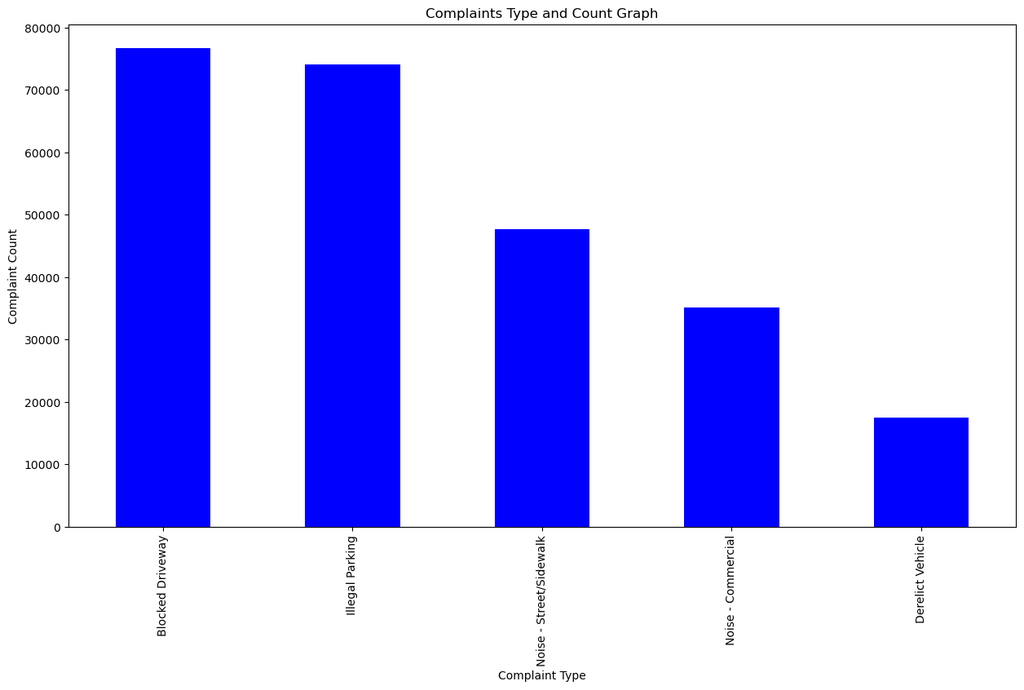

```python
# Visualize them in a graph

plt.figure(figsize = (15,8))
complaints.plot(kind='bar', color = "blue")
plt.title('Complaints Type and Count Graph')
plt.ylabel("Complaint Count")
plt.xlabel("Complaint Type")
plt.show()
```

#### Insight 2: Top 5 Borough with Highest Complaint

```python
# Compute the complaint frequency for each city and complaint type

complaints_and_city = pd.crosstab(index=dataSet["Borough"], columns=dataSet["Complaint Type"])

# Sum the complaints by city (summing over the complaint types)
row_sums = complaints_and_city.sum(axis=1)

# Top 5 cities with the highest complaint number
Top_5 = row_sums.sort_values(ascending=False).head()
Top_5
```

```
Borough
BROOKLYN         96858
QUEENS           79790
MANHATTAN        62033
BRONX            40217
STATEN ISLAND    12209
dtype: int64
```

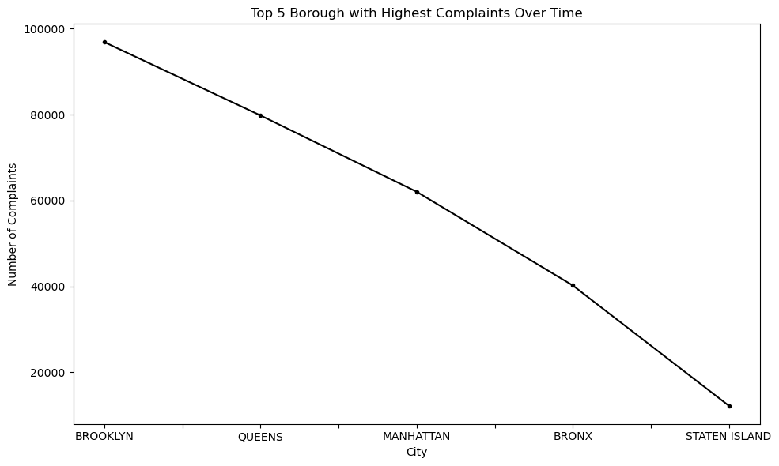

```python
# Plotting the top 5 cities with the highest complaint numbers

plt.figure(figsize=(10, 6))
Top_5.plot(kind='line', marker='.', color='black')
plt.title("Top 5 Borough with Highest Complaints Over Time")
plt.xlabel("City")
plt.ylabel("Number of Complaints")
plt.tight_layout()
plt.show()
```

#### Insight 3: Compliant Type Distribution In Brooklyn

```python
# Filter data for one city

city_name = 'Brooklyn'  # Change this to any city
city_data = dataSet[dataSet['City'].str.upper() == city_name.upper()]

# Count complaint types in that city
complaint_counts = city_data['Complaint Type'].value_counts()

# Set a threshold for small complaint types (e.g., less than 10 complaints)
threshold = 2000
other_complaints = complaint_counts[complaint_counts < threshold]

# Group all small complaint types as 'Other'
complaint_counts = complaint_counts[complaint_counts >= threshold]
complaint_counts['Other'] = other_complaints.sum()
```

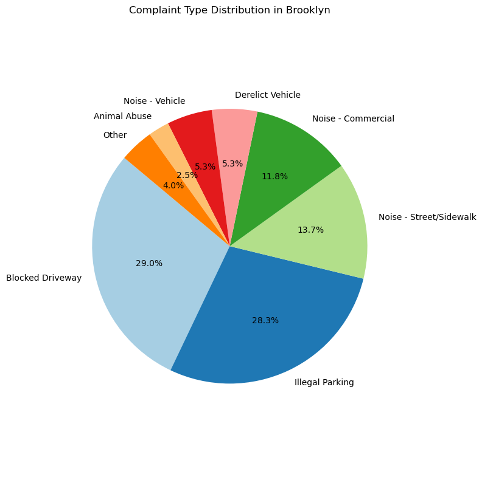

```python
# Plot pie chart

plt.figure(figsize=(8, 8))
plt.pie(complaint_counts, labels=complaint_counts.index, autopct='%1.1f%%', startangle=140, colors=plt.cm.Paired.colors)
plt.title(f'Complaint Type Distribution in {city_name.title()}')
plt.axis('equal')  # Keeps pie circular
plt.tight_layout()
plt.show()
```

#### Insight 4: Number of Complaints per Moth

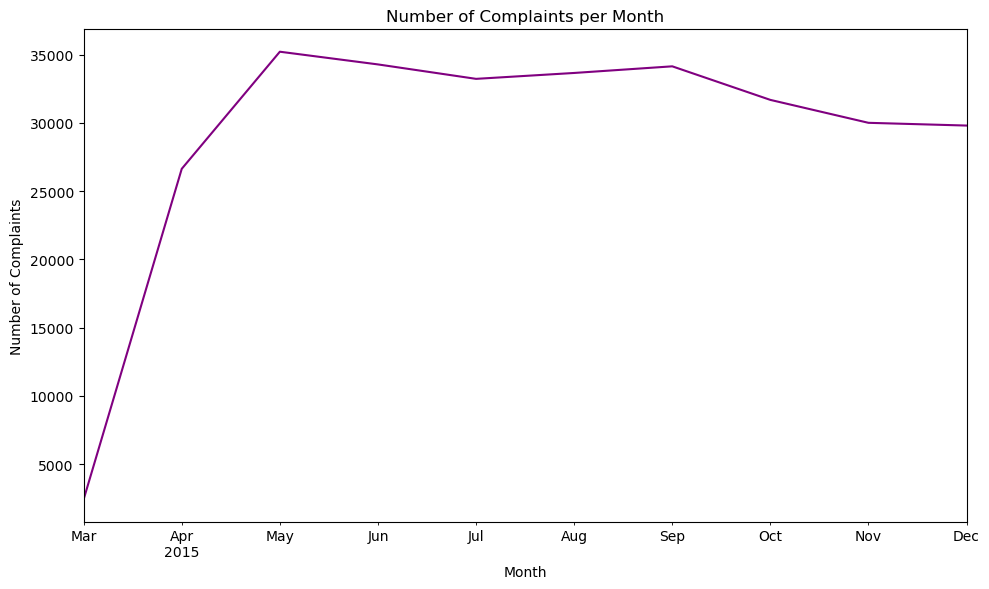

```python
dataSet['Created Date'] = pd.to_datetime(dataSet['Created Date'])
monthly_complaints = dataSet.set_index('Created Date').resample('ME').size()
monthly_complaints.plot(figsize=(10, 6), color='purple')

#Plotting

plt.title('Number of Complaints per Month')
plt.xlabel('Month')
plt.ylabel('Number of Complaints')
plt.tight_layout()
plt.show()
```

## 4.2 Arrange the complaint types according to their average 'Request_Closing_Time', categorized by various locations. Illustrate it through graph as well.

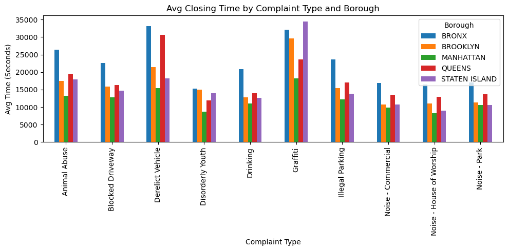

```python
# Compute pivot: average closing time by complaint type and borough
pivot = dataSet.groupby(['Complaint Type','Borough'])['Request_Closing_Time_Int'].mean().unstack().head(10)

# Plotting in the graph

pivot.plot(kind='bar', figsize=(10,5))
plt.title("Avg Closing Time by Complaint Type and Borough")
plt.xlabel("Complaint Type")
plt.ylabel("Avg Time (Seconds)")
plt.legend(title="Borough")
plt.tight_layout()
plt.show()
```

# 5 Statical Testing

## Test 1 : Whether the average response time across complaint types is similar or not.

### We will be performing One-Way ANOVA Test because:

### Null hypothesis (H0) = The average response time across all the complaint types is the similar

### Example:

### Let 'X' be the average closing time for complaint types, and let 5 be the total number of complaints.

### Then, according to the Null Hypothesis, all of the average closing times is similar

### a * X1 = b * X2 = c * X3 = d * X4 = e * X5 (a,b,c,d,e are negligible constants)

### Alternate hypothesis (H1) = The average response time across complaint types is not similar

### Example:

### Let 'X' be the average closing time for complaint types, and let 3 be the total number of complaints.

### Then, according to the Alternate Hypothesis, at least one of the average closing time is not equal

### Either: X1 != X2 or X2 != X3 or X1 != X3

```python
# Grouping by Complaint Type

complaint_groups = dataSet.groupby('Complaint Type')['Request_Closing_Time_Int']

# Performing One-way ANOVA

f_stat, p_value = stats.f_oneway(*[group for name, group in complaint_groups])
print(f'We got ANOVA F-statistic: {f_stat}')
print(f'We got P-value: {p_value}')

print("")
# Checking the output

if p_value <= 0.05:
    print('We Accept the Alternative hypothesis, The average response time across all the complaint types is not similar')
else:
    print('We Accept the Null hypothesis, The average response time across complaint types is similar')
```

```
We got ANOVA F-statistic: 578.9120337398357
We got P-value: 0.0

We Accept the Alternative hypothesis, The average response time across all the complaint types is not similar
```

## Test 2: Whether the type of complaint or service requested and location are related.

### Here, we will be performing the Chi-Square Test of independence because:

### Both variables (complaint type and location) are categorical.

### We want to find the association between the two categorical variables.

### Stating the hypothesis:

### Null Hypothesis (H0): The complaint type and location are not related

### Alternate Hypothesis (H1): The complaint type and location are related

## Performing Chi-Square Test of Independence

```python
# Create a contingency table (cross-tabulation) between Complaint Type and Location

table = pd.crosstab(dataSet['Complaint Type'], dataSet['Borough'])

# Perform the Chi-Square Test of Independence
chi2_stat, p_value, dof, expected = stats.chi2_contingency(table)

# Print the results
print(f'We got Chi-Square Statistic: {chi2_stat}')
print(f'We got P-value: {p_value}')

print("")

# Interpretation of the results
if p_value <= 0.05:
    print("We Accept the Alternative hypothesis: There Complaint Type and Location are related.")
else:
    print("We Accept the null hypothesis: There Complaint Type and Location are not related.")
```

```
We got Chi-Square Statistic: 73264.62164334783
We got P-value: 0.0

We Accept the Alternative hypothesis: There Complaint Type and Location are related.
```